# Radiometric calibration with reference surfaces using the thermal package

# Introduction

In addition to correcting drift in thermal infrared (TIR) images, the `thermal` package can perform radiometric calibration of images or orthomosaics by combining images with information on the temperature and position of reference surfaces. This vignette will show a step-by-step procedure to perform such radiometric calibration, i.e., translating digital number (DN) values returned by a camera into actual surface temperature readings.

# Dataset

The dataset used here is based on the same flight as the vignette on thermal drift correction, which we advise to read first. In brief, this dataset comprises 30 TIR images taken around noon on September 1, 2023.

Of particular importance for this vignette is that three reference sufaces were placed in the study area during the flight for the purposes of radiometric calibration. Those surfaces are aluminum panels painted with matte paint for concrete of three different colors (black, gray and white) to allow for differences in panel temperature through absorbed solar radiation. The temperature of the panels was monitored by type T thermocouples plugged into CR1000X dataloggers that recorded temperature every five seconds. This allowed thermal infrared radiation as detected by the camera to be directly linked to high-quality temperature measurements which we will use for radiometric calibration.

The images were downgraded from their original 640x512 resolution to 80x64 to reduce their size for shipping along with the package and to speed up processing for testing purposes. While the quality of the images is reduced, this is of little relevance to the examples presented in this vignette.

Image metadata can be read using the `read_metadata` function:

```r
# Loading the package
library(thermal)

# The functions would work without explicitly loading the sf package
# However, this will enhance the display of spatial objects in this vignette
library(sf)
```

```r
# Getting a vector of absolute paths to the test TIR images
thermal_files <- dir(system.file("extdata", package = "thermal"),
                     pattern = "thermal\\.tiff$", full.names = TRUE)

# Reading metadata from EXIF tags
# Setting the proper display time zone is critical here because we need to
# match the time zone of the separately recorded surface temperature data
tmeta_df <- read_metadata(thermal_files,
                          camera_tz = "Etc/GMT+5",
                          display_tz = "Etc/GMT+4",
                          tags = "minimal")

# Providing IDs for each picture as row names
# This is necessary to match the panel coordinates with each picture
rownames(tmeta_df) <- substr(basename(tmeta_df$SourceFile), 1, 8)

head(tmeta_df)
```

```
#>                                                                              SourceFile
#> DJI_0665 /tmp/RtmpA3E5Zt/temp_libpath670a3e13abfe/thermal/extdata/DJI_0665_thermal.tiff
#> DJI_0671 /tmp/RtmpA3E5Zt/temp_libpath670a3e13abfe/thermal/extdata/DJI_0671_thermal.tiff
#> DJI_0677 /tmp/RtmpA3E5Zt/temp_libpath670a3e13abfe/thermal/extdata/DJI_0677_thermal.tiff
#> DJI_0683 /tmp/RtmpA3E5Zt/temp_libpath670a3e13abfe/thermal/extdata/DJI_0683_thermal.tiff
#> DJI_0689 /tmp/RtmpA3E5Zt/temp_libpath670a3e13abfe/thermal/extdata/DJI_0689_thermal.tiff
#> DJI_0695 /tmp/RtmpA3E5Zt/temp_libpath670a3e13abfe/thermal/extdata/DJI_0695_thermal.tiff
#>          GimbalYawDegree          CreateDate    DateTimeOriginal
#> DJI_0665           166.2 2023-09-01 11:59:34 2023-09-01 11:59:34
#> DJI_0671          -179.5 2023-09-01 11:59:47 2023-09-01 11:59:47
#> DJI_0677          -178.6 2023-09-01 12:00:00 2023-09-01 12:00:00
#> DJI_0683          -178.4 2023-09-01 12:00:13 2023-09-01 12:00:13
#> DJI_0689           -92.7 2023-09-01 12:00:22 2023-09-01 12:00:22
#> DJI_0695             0.0 2023-09-01 12:00:35 2023-09-01 12:00:35
#>          GPSLongitudeRef GPSLatitudeRef GPSAltitudeRef GPSLongitude GPSLatitude
#> DJI_0665               W              N              0    -78.21597    48.53265
#> DJI_0671               W              N              0    -78.21602    48.53249
#> DJI_0677               W              N              0    -78.21603    48.53232
#> DJI_0683               W              N              0    -78.21603    48.53214
#> DJI_0689               W              N              0    -78.21615    48.53210
#> DJI_0695               W              N              0    -78.21614    48.53227
#>          GPSAltitude GPSMapDatum
#> DJI_0665       335.7       WGS84
#> DJI_0671       335.5       WGS84
#> DJI_0677       335.6       WGS84
#> DJI_0683       335.6       WGS84
#> DJI_0689       335.6       WGS84
#> DJI_0695       335.7       WGS84
```

For the sake of radiometric calibration, we also provided row names to the metadata. We will use these as IDs to uniquely identify individual pictures and link them to the coordinates of the reference surfaces.

# Formatting data for radiometric calibration

Radiometric calibration of TIR images requires two additional sources of data in addition to the images themselves:

- Spatial location of the reference surfaces in the images
- Time series of temperature for each of the reference surfaces

These are included in the package as datasets with names `panels` and `temperature`, respectively. The `panels` dataset is list of `sf` objects with the coordinates of the reference surfaces (panels) in each of the images:

```r
length(panels)
```

```
#> [1] 27
```

```r
head(panels, n = 3)
```

```
#> $DJI_0671
#> Simple feature collection with 3 features and 1 field
#> Geometry type: POLYGON
#> Dimension:     XY
#> Bounding box:  xmin: 64.01917 ymin: 46.77903 xmax: 71.72816 ymax: 48.37238
#> CRS:           NA
#>                                x    ID
#> 1 POLYGON ((71.72816 46.9295,... black
#> 2 POLYGON ((65.44456 46.86963...  gray
#> 3 POLYGON ((69.18277 47.03898... white
#>
#> $DJI_0677
#> Simple feature collection with 3 features and 1 field
#> Geometry type: POLYGON
#> Dimension:     XY
#> Bounding box:  xmin: 64.2194 ymin: 28.44002 xmax: 71.95437 ymax: 30.01581
#> CRS:           NA
#>                                x    ID
#> 1 POLYGON ((71.95437 28.44002... black
#> 2 POLYGON ((65.59797 28.59789...  gray
#> 3 POLYGON ((69.38626 28.64031... white
#>
#> $DJI_0683
#> Simple feature collection with 3 features and 1 field
#> Geometry type: POLYGON
#> Dimension:     XY
#> Bounding box:  xmin: 63.95457 ymin: 7.62984 xmax: 71.68678 ymax: 9.569316
#> CRS:           NA
#>                                x    ID
#> 1 POLYGON ((71.66044 7.62984,... black
#> 2 POLYGON ((65.27967 8.169229...  gray
#> 3 POLYGON ((69.09201 7.985173... white
```

The number of objects in the list is 27 rather than 30 (the total number of images) because three of the images did not include the panels in their frame. The names of the list elements (`DJI_0671`, `DJI_0677`, `DJI_0683`, …) link the panel coordinates to the image that they relate to. In addition to the panel coordinates, the `ID` column of each sf object identifies the panel that they correspond to.

Getting the panel coordinates in the right format for radiometric calibration (named list of sf objects, with an `ID` column for the identifier of the surface) is probably the trickiest part of conducting radiometric calibration. The panel coordinates of the dataset used here were obtained through a semi-automated approach, but `thermal` also provides the function `create_surfaces` to interactively and graphically derive surface coordinates from the `R` console.

`thermal` also provides the `temperature` object as an example of surface temperature data to be used for radiometric calibration:

```r
str(temperature)
```

```
#> List of 3
#>  $ black:'data.frame':   6264 obs. of  2 variables:
#>   ..$ time: POSIXct[1:6264], format: "2023-09-01 08:42:55" "2023-09-01 08:43:00" ...
#>   ..$ temp: num [1:6264] 20.6 20.8 21 21.2 21.4 ...
#>  $ gray :'data.frame':   6169 obs. of  2 variables:
#>   ..$ time: POSIXct[1:6169], format: "2023-09-01 08:46:55" "2023-09-01 08:47:00" ...
#>   ..$ temp: num [1:6169] 14.6 14.5 14.4 14.3 14.4 ...
#>  $ white:'data.frame':   6225 obs. of  2 variables:
#>   ..$ time: POSIXct[1:6225], format: "2023-09-01 08:45:35" "2023-09-01 08:45:40" ...
#>   ..$ temp: num [1:6225] 16.8 16.6 16.3 16.2 16 ...
```

The package does not provide functions to read temperature data given the diversity of formats in which such data may be provided. However, as long as the following guidelines are followed for formatting temperature data, downstream analyses should work seamlessly:

- Data is provided as a list with as many elements as the number of reference surfaces used.
- The name of each list element should match the `"ID"` column of the objects containing surface coordinates.
- Each list element should be a data.frame containing the columns `"time"` (vector of class POSIXct in the same time zone as the timestamps of the images) and `"temp"` (surface temperature). Here, the temperature is provided in degrees Celsius, but any temperature scale should work.

The function `plot_temp` is provided to display the time series of temperature data, with one line per reference surface. By default, all lines will be black, but here we request specific colors for each surface and add a legend to the plot.

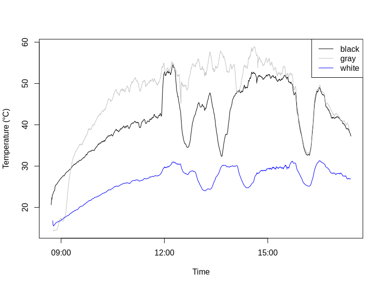

```r
plot_temp(temperature,
          lcol = c("black" = "black", "gray" = "gray", "white" = "blue"),
          legend.pos = "topright")
```

Plotting the location of the panels on top of the thermal images is easy using functionality from the `sf` and `terra` packages:

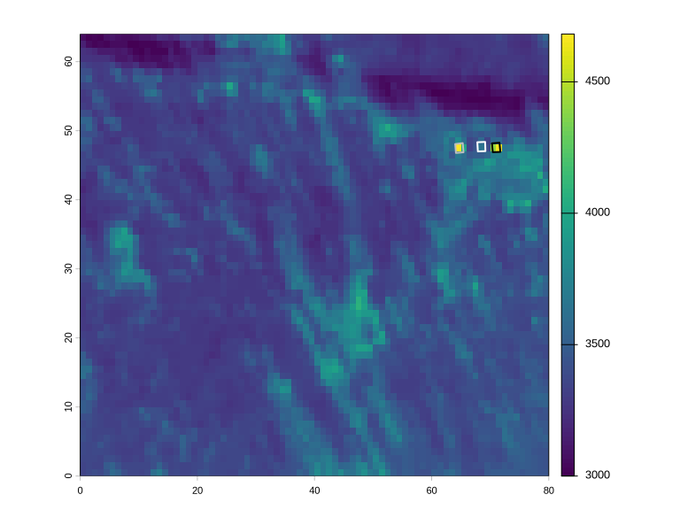

```r
# We can use identifiers to index the metadata because we have set row names
terra::plot(terra::rast(tmeta_df["DJI_0671", "SourceFile"], noflip = TRUE))

# The argument add = TRUE plots the shapes on top of the raster
plot(panels[["DJI_0671"]],
     col = "transparent",
     border = c("black", "gray", "white"),
     lwd = 2, add = TRUE)
```

Although image resolution is low, we can see that the black and gray panels are warmer than the white one, as we would expect.

# Rationale for radiometric calibration with `thermal`

The `thermal` package performs radiometric calibration by assuming linear models to compute surface temperature from thermal DN. By default, the functions used to compute these linear models will summarize the pixels corresponding to a given surface to a single value representing the maximum density of the DN distribution. This summarized measure is less sensitive to pixels ouside the surface than would be the mean, for example. However, other functions can be provided to summarize the pixels corresponding to each surface.

Using the default approach means that, in the case of the test dataset, linear models of temperature will be computed for each image from three values, one for each of the panels. As we will see below, it is also possible to fit a linear model of radiometric calibration from all images taken during a flight which include the reference surfaces instead of from a single image.

# Basic functionality: fitting linear models of temperature as a function of digital number

From a practical standpoint, fitting linear models of surface temperature as a function of thermal DN involves the following steps for each picture:

- Getting the temperature corresponding to each surface at the time when the picture was taken.
- Retrieving the values of the pixels corresponding to the surfaces.
- Optionally processing the distribution of DN values to summarize or filter them.
- Using the temperature and DN data to fit a linear model.

Many of these steps occur under the hood, but it is important to understand the sequence of computations because `thermal` exposes functionality to manipulate some of these steps through the functions `add_temp_metadata` and `thermal_lm`.

The function `add_temp_metadata` adds columns for the temperature of the reference surfaces to the data.frame of flight metadata. Using the flight metadata and surface temperature as input, it will create a new temperature column for each of the reference surfaces. The temperature values are queried such that they are the closest measurement in time to when each picture was taken. A user-controllable threshold returns an error when no temperature measurement is close enough (default: 10 seconds) to a picture.

```r
# Will return an error if any picture was taken more than 5 seconds apart from
# the closest temperature measurement
tmeta_df <- add_temp_metadata(tmeta_df, temperature, tolerance = as.difftime(5, units = "secs"))

head(tmeta_df)
```

```
#>                                                                              SourceFile
#> DJI_0665 /tmp/RtmpA3E5Zt/temp_libpath670a3e13abfe/thermal/extdata/DJI_0665_thermal.tiff
#> DJI_0671 /tmp/RtmpA3E5Zt/temp_libpath670a3e13abfe/thermal/extdata/DJI_0671_thermal.tiff
#> DJI_0677 /tmp/RtmpA3E5Zt/temp_libpath670a3e13abfe/thermal/extdata/DJI_0677_thermal.tiff
#> DJI_0683 /tmp/RtmpA3E5Zt/temp_libpath670a3e13abfe/thermal/extdata/DJI_0683_thermal.tiff
#> DJI_0689 /tmp/RtmpA3E5Zt/temp_libpath670a3e13abfe/thermal/extdata/DJI_0689_thermal.tiff
#> DJI_0695 /tmp/RtmpA3E5Zt/temp_libpath670a3e13abfe/thermal/extdata/DJI_0695_thermal.tiff
#>          GimbalYawDegree          CreateDate    DateTimeOriginal
#> DJI_0665           166.2 2023-09-01 11:59:34 2023-09-01 11:59:34
#> DJI_0671          -179.5 2023-09-01 11:59:47 2023-09-01 11:59:47
#> DJI_0677          -178.6 2023-09-01 12:00:00 2023-09-01 12:00:00
#> DJI_0683          -178.4 2023-09-01 12:00:13 2023-09-01 12:00:13
#> DJI_0689           -92.7 2023-09-01 12:00:22 2023-09-01 12:00:22
#> DJI_0695             0.0 2023-09-01 12:00:35 2023-09-01 12:00:35
#>          GPSLongitudeRef GPSLatitudeRef GPSAltitudeRef GPSLongitude GPSLatitude
#> DJI_0665               W              N              0    -78.21597    48.53265
#> DJI_0671               W              N              0    -78.21602    48.53249
#> DJI_0677               W              N              0    -78.21603    48.53232
#> DJI_0683               W              N              0    -78.21603    48.53214
#> DJI_0689               W              N              0    -78.21615    48.53210
#> DJI_0695               W              N              0    -78.21614    48.53227
#>          GPSAltitude GPSMapDatum black  gray white
#> DJI_0665       335.7       WGS84 52.50 54.42 29.66
#> DJI_0671       335.5       WGS84 52.53 54.16 29.67
#> DJI_0677       335.6       WGS84 52.68 53.93 29.69
#> DJI_0683       335.6       WGS84 52.84 53.73 29.80
#> DJI_0689       335.6       WGS84 52.85 53.66 29.79
#> DJI_0695       335.7       WGS84 52.65 53.42 29.68
```

As can be seen from the output above, three new columns have been added to the metadata, one for the temperature of each of the three panels.

Next, the function `thermal_lm` fits the radiometric calibration models by combining information from three sources: the thermal infrared images, the spatial location of the reference surfaces in the images, and the temperature of the surfaces at the time when the pictures were taken. This step requires the row names of the flight metadata to match the IDs of the spatial polygons representing the positions of the panels as these IDs will be used to associate the polygons with their image. The images themselves do not need to be explicitly loaded in memory. They will instead be read on the fly from the path to the `SourceFile` listed in the metadata. Therefore, it is preferable to read the metadata using absolute file paths when using `read_metadata`.

Internally, `thermal_lm` will first extract the pixels corresponding to each surface from the images. A function has to be provided to process the distribution of DN values obtained, for example by using the mean or median. The values can also be filtered or left as is, in which case the radiometric calibration model will be fitted on several values per panel. By default, the function used is `max_density`, a function that determines where the density of the distribution is maximal. However, since the images that we use here have very low resolution, we will use the median instead such that the analysis works even with a single pixel per surface.

Once the DN values of a surface have been extracted and processed, `thermal_lm` will fit one linear model of surface temperature as a function of measured thermal infrared radiation for each picture in the dataset for which such information is available. The `surfaces` argument controls which surfaces we want to include in the computation of the models. Here, we use them all.

```r
# Parallel processing is supported through argument ncores
# However, this does not work on Windows as it uses function mclapply from the
# parallel package
thermal_models <- thermal_lm(metadata = tmeta_df,
                             polygons = panels,
                             summary_functions = median,
                             surfaces = c("black", "gray", "white"),
                             ncores = if(.Platform$OS.type == "unix") 2 else 1)
```

The value returned by `thermal_lm` is a list of three elements, the first of which is the flight metadata updated with the results of the linear models for each picture. Pictures for which no panels were in the frame display `NA` for linear model-related columns `slope` and `intercept`:

```r
head(thermal_models$metadata)
```

```
#>                                                                              SourceFile
#> DJI_0665 /tmp/RtmpA3E5Zt/temp_libpath670a3e13abfe/thermal/extdata/DJI_0665_thermal.tiff
#> DJI_0671 /tmp/RtmpA3E5Zt/temp_libpath670a3e13abfe/thermal/extdata/DJI_0671_thermal.tiff
#> DJI_0677 /tmp/RtmpA3E5Zt/temp_libpath670a3e13abfe/thermal/extdata/DJI_0677_thermal.tiff
#> DJI_0683 /tmp/RtmpA3E5Zt/temp_libpath670a3e13abfe/thermal/extdata/DJI_0683_thermal.tiff
#> DJI_0689 /tmp/RtmpA3E5Zt/temp_libpath670a3e13abfe/thermal/extdata/DJI_0689_thermal.tiff
#> DJI_0695 /tmp/RtmpA3E5Zt/temp_libpath670a3e13abfe/thermal/extdata/DJI_0695_thermal.tiff
#>          GimbalYawDegree          CreateDate    DateTimeOriginal
#> DJI_0665           166.2 2023-09-01 11:59:34 2023-09-01 11:59:34
#> DJI_0671          -179.5 2023-09-01 11:59:47 2023-09-01 11:59:47
#> DJI_0677          -178.6 2023-09-01 12:00:00 2023-09-01 12:00:00
#> DJI_0683          -178.4 2023-09-01 12:00:13 2023-09-01 12:00:13
#> DJI_0689           -92.7 2023-09-01 12:00:22 2023-09-01 12:00:22
#> DJI_0695             0.0 2023-09-01 12:00:35 2023-09-01 12:00:35
#>          GPSLongitudeRef GPSLatitudeRef GPSAltitudeRef GPSLongitude GPSLatitude
#> DJI_0665               W              N              0    -78.21597    48.53265
#> DJI_0671               W              N              0    -78.21602    48.53249
#> DJI_0677               W              N              0    -78.21603    48.53232
#> DJI_0683               W              N              0    -78.21603    48.53214
#> DJI_0689               W              N              0    -78.21615    48.53210
#> DJI_0695               W              N              0    -78.21614    48.53227
#>          GPSAltitude GPSMapDatum black  gray white blackpix graypix whitepix
#> DJI_0665       335.7       WGS84 52.50 54.42 29.66       NA      NA       NA
#> DJI_0671       335.5       WGS84 52.53 54.16 29.67   4530.0  4682.0   3644.0
#> DJI_0677       335.6       WGS84 52.68 53.93 29.69   4491.0  4288.5   3590.0
#> DJI_0683       335.6       WGS84 52.84 53.73 29.80   4475.5  4339.0   3608.0
#> DJI_0689       335.6       WGS84 52.85 53.66 29.79   4439.5  4578.0   3487.0
#> DJI_0695       335.7       WGS84 52.65 53.42 29.68   4683.0  4340.0   3457.5
#>          intercept      slope
#> DJI_0665        NA         NA
#> DJI_0671 -58.91577 0.02435496
#> DJI_0677 -69.56214 0.02789009
#> DJI_0683 -73.03406 0.02861519
#> DJI_0689 -49.32085 0.02273282
#> DJI_0695 -39.46257 0.02036278
```

While most of the necessary information for downstream analyses is embedded in that metadata, other outputs are stored to allow for quality control and troubleshooting. For example, the second element of the list contains the models themselves:

```r
# Looking at the linear model for the first image
thermal_models$models[["DJI_0671"]]
```

```
#>
#> Call:
#> stats::lm(formula = temp ~ pixel, data = model_data)
#>
#> Coefficients:
#> (Intercept)        pixel
#>   -58.91577      0.02435
```

Finally, the third element of the returned list contains information on the values of all the pixels that were extracted from the reference surfaces, prior to being processed through the summary functions. This can be useful for diagnosing any issues with radiometric calibration.

```r
head(thermal_models$pixels)
```

```
#> $DJI_0671
#>      ID thermal  temp
#> 1 black    4407 52.53
#> 2 black    4653 52.53
#> 3  gray    4682 54.16
#> 4 white    3644 29.67
#>
#> $DJI_0677
#>      ID thermal  temp
#> 1 black    4538 52.68
#> 2 black    4444 52.68
#> 3  gray    4225 53.93
#> 4  gray    4352 53.93
#> 5 white    3590 29.69
#>
#> $DJI_0683
#>      ID thermal  temp
#> 1 black    4354 52.84
#> 2 black    4597 52.84
#> 3  gray    4107 53.73
#> 4  gray    4571 53.73
#> 5 white    3608 29.80
#>
#> $DJI_0689
#>      ID thermal  temp
#> 1 black    4446 52.85
#> 2 black    4433 52.85
#> 3  gray    4578 53.66
#> 4 white    3470 29.79
#> 5 white    3504 29.79
#>
#> $DJI_0695
#>      ID thermal  temp
#> 1 black    4683 52.65
#> 2  gray    4340 53.42
#> 3 white    3377 29.68
#> 4 white    3538 29.68
#>
#> $DJI_0701
#>      ID thermal  temp
#> 1 black    4721 52.44
#> 2  gray    4512 52.93
#> 3 white    3367 29.79
#> 4 white    3379 29.79
#> 5 white    3458 29.79
#> 6 white    3488 29.79
```

# Quality control and advanced functionality

At this stage, it may by worth assessing the results critically. We can use the function `plot_pixtemp` to look at the linear models and the temperature/DN values that they were fitted with. The argument `lcol` allows to specify the colors to use for displaying the data of each reference surface whereas the argument `id` allows to identify a vector of images to display (by default, it will display them all). The red points show the summarized values (here, the median) that were used to fit the models.

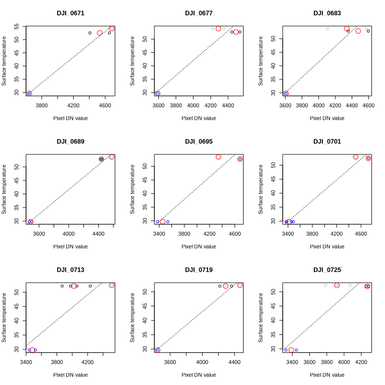

```r
# We will display data for the first 9 images
par(mfrow = c(3, 3))

plot_pixtemp(model_data = thermal_models,
             id = names(panels)[1:9],
             lcol = c(black = "black", gray = "gray", white = "blue"))
```

We can see that the models are a bit off for some of the images, which is to be expected given the low resolution of the images that we are using. If we were to do any serious analysis using this data, it would be worth removing these pictures or finding out why their results are bad.

It is also possible to use different summary functions to summarize the data for different reference surfaces (for example, if the distinct properties of the surfaces warrant it) by providing a named list of functions with each name corresponding to the ID of a surface. For example, let us suppose that for some reason we want to use the the mean for the white panel, the median for the gray panel, and all values for the black panel. Such models can be fitted and visualized as follows:

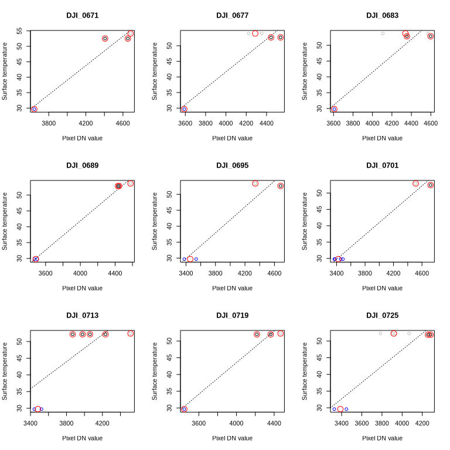

```r
alternative_models <- thermal_lm(metadata = tmeta_df,
                                 polygons = panels,
                                 summary_functions = c(white = mean,
                                                       gray = median,
                                                       black = identity),
                                 surfaces = c("black", "gray", "white"),
                                 ncores = if(.Platform$OS.type == "unix") 2 else 1)

par(mfrow = c(3, 3))

plot_pixtemp(model_data = alternative_models,
             id = names(panels)[1:9],
             lcol = c(black = "black", gray = "gray", white = "blue"))
```

Alternatively, we may want to fit the models using only the white and black panels because we have found that the temperature or DN values of the gray panel could not be trusted for this flight:

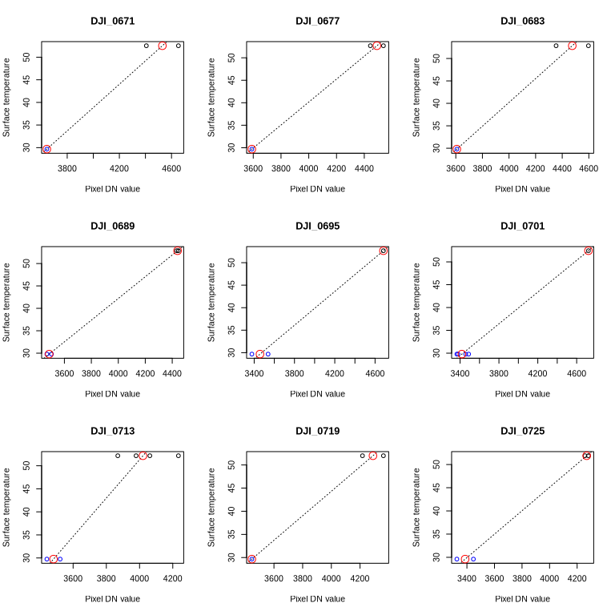

```r
bw_models <- thermal_lm(metadata = tmeta_df,
                        polygons = panels,
                        summary_functions = median,
                        surfaces = c("black", "white"),
                        ncores = if(.Platform$OS.type == "unix") 2 else 1)

par(mfrow = c(3, 3))

plot_pixtemp(model_data = bw_models,
             id = names(panels)[1:9],
             lcol = c(black = "black", white = "blue"))
```

Finally, we may be interested in using the data to fit a global radiometric calibration model for the whole flight instead of using models that were individually fitted from each image. The `global_lm` function accomplishes this by using the output from `thermal_lm` to fit a model on the data that was already summarized for a whole flight. The object returned by `global_lm` has the same structure as the one returned by `thermal_lm` and can thus also be visualized with `plot_pixtemp` to see what data were used to fit the model:

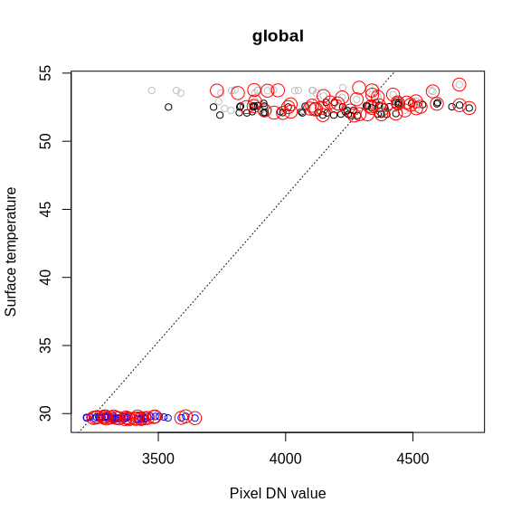

```r
global_model <- global_lm(thermal_models)

plot_pixtemp(model_data = global_model,
             lcol = c(black = "black", gray = "gray", white = "blue"))
```

# Radiometric calibration and drift correction

It may also be worth looking at the shift in linear model parameters over time, which may be an indication of thermal drift occurring. We will look at the intercept, slope, and the predicted temperature for a relatively average DN of 3500.

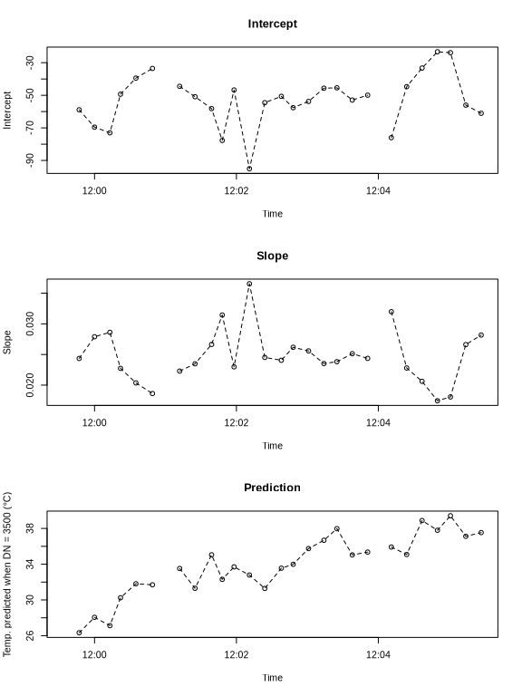

```r
# We rename tmeta_df to the metadata stored by the output of thermal_models
tmeta_df <- thermal_models$metadata

par(mfrow = c(3, 1))

# A plot of linear model intercept over time
plot(tmeta_df$DateTimeOriginal, tmeta_df$intercept,
     main = "Intercept", xlab = "Time", ylab = "Intercept")
lines(tmeta_df$DateTimeOriginal, tmeta_df$intercept, lty = 2)

# A plot of linear model slope over time
plot(tmeta_df$DateTimeOriginal, tmeta_df$slope,
     main = "Slope", xlab = "Time", ylab = "Slope")
lines(tmeta_df$DateTimeOriginal, tmeta_df$slope, lty = 2)

# A plot of temperature predicted from a DN of 3500 from models fitted at various time points
plot(tmeta_df$DateTimeOriginal,  3500 * tmeta_df$slope + tmeta_df$intercept,
     main = "Prediction", xlab = "Time", ylab = "Temp. predicted when DN = 3500 (°C)")
lines(tmeta_df$DateTimeOriginal, 3500 * tmeta_df$slope + tmeta_df$intercept, lty = 2)
```

It is clear from the plot above that drift is occurring in the dataset. Indeed, the temperature predicted from a fixed DN value varies depending on the image that was used to fit the models, indicating instability in radiometric calibration parameters. If we correct the images assuming a linear model of drift, the results are considerably improved, although not perfect:

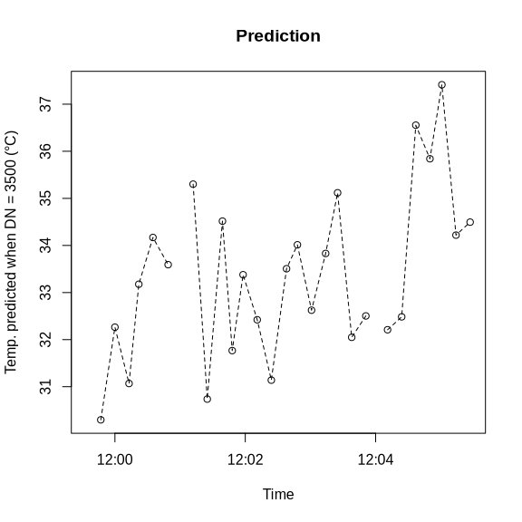

```r
corrected_df <- read_metadata(thermal_files,
                              camera_tz = "Etc/GMT+5",
                              display_tz = "Etc/GMT+4",
                              tags = "minimal")

corrected_df <- correct_thermal(metadata = corrected_df,
                                correction_type = "lm",
                                output_dir = tempdir(),
                                camera_tz = "Etc/GMT+5",
                                display_tz = "Etc/GMT+4",
                                tags = "minimal",
                                nuc_threshold = 80,
                                overwrite_dst = TRUE,
                                verbose = FALSE)

rownames(corrected_df) <- substr(basename(corrected_df$SourceFile), 1, 8)

corrected_df <- add_temp_metadata(corrected_df, temperature,
                                  tolerance = as.difftime(5, units = "secs"))

corrected_models <- thermal_lm(metadata = corrected_df,
                               polygons = panels,
                               summary_functions = median,
                               surfaces = c("black", "gray", "white"),
                               ncores = if(.Platform$OS.type == "unix") 2 else 1)

# Extracting the metadata from the output of thermal_lm
corrected_df <- corrected_models$metadata

# A plot of temperature predicted from a DN of 3500 from models fitted at various time points
plot(corrected_df$DateTimeOriginal,  3500 * corrected_df$slope + corrected_df$intercept,
     main = "Prediction", xlab = "Time", ylab = "Temp. predicted when DN = 3500 (°C)")
lines(x = corrected_df$DateTimeOriginal,
      y = 3500 * corrected_df$slope + corrected_df$intercept,
      lty = 2)
```

Although far from perfect, the stability of the predictions is better in the corrected data

# Computing surface temperature from radiometric calibration models

Finally, we can use the radiometric calibration models to compute surface temperature for the images acquired during the flight. We can simply use the function `thermal_predict` with the model that we deem the best to predict the surface temperature from the DN values of a given raster. Here, we will fit a global model from the drift-corrected images used in the previous step:

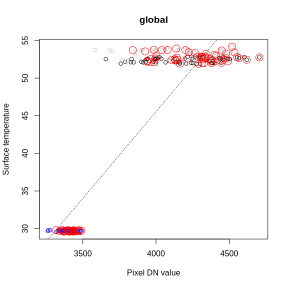

```r
global_corrected <- global_lm(corrected_models)

plot_pixtemp(global_corrected,
             lcol = c(black = "black", gray = "gray", white = "blue"))
```

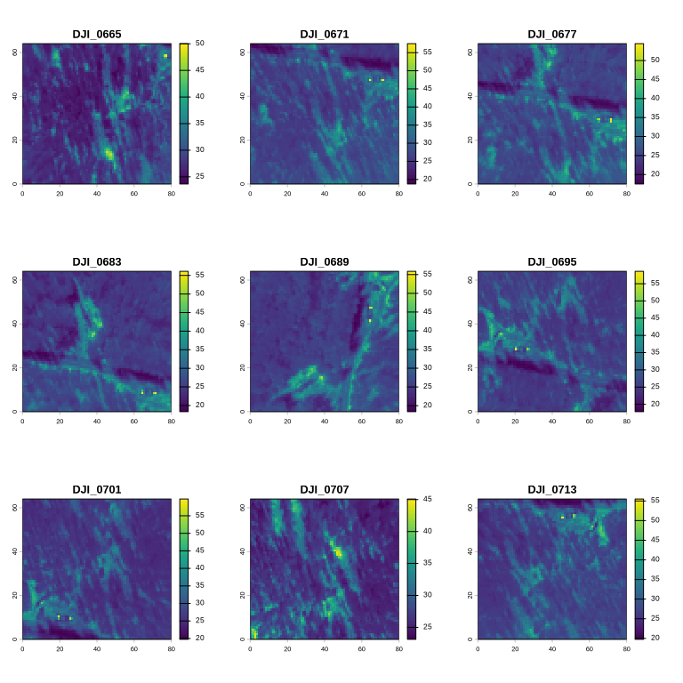

```r
par(mfrow = c(3, 3))

for(i in rownames(corrected_df)[1:9]) {
        i_rast <- terra::rast(corrected_df[i, "SourceFile"], noflip = TRUE)
        i_rast <- thermal_predict(x = i_rast, model = global_corrected$models$global)
        terra::plot(i_rast, main = i)
}
```

# Session info